# Instalacja i ładowanie pakietów

```r
packages <- c("ggplot2", "dplyr", "tidyverse", "readr", "corrplot", "sf",
              "spatialreg", "spdep", "naniar", "e1071", "standardize", "prettydoc")

for (pkg in packages) {
  if (!require(pkg, character.only = TRUE)) {
    install.packages(pkg)
    library(pkg, character.only = TRUE)
  } else {
    library(pkg, character.only = TRUE)
  }
}

library(naniar)
library(ggplot2)
library(dplyr)
library(e1071)
library(ggplot2)
library(dplyr)
library(tidyverse)
library(readr)
library(corrplot)
library(sf)
library(spatialreg)
library(spdep)
library(naniar)
library(standardize)
library(prettydoc)
```

# Wstęp

W niniejszym raporcie przedstawiono analizę zanieczyszczenia powietrza w Polsce z wykorzystaniem danych przestrzennych oraz narzędzi statystycznych w języku R.

# Wyjaśnienie zmiennej objaśnianej i zmiennych objaśniających

## Zmienna objaśniana

Wskaźnik zanieczyszczenia powietrza

Zmienna objaśniana w analizowanym modelu stanowi syntetyczny wskaźnik zanieczyszczenia powietrza, będący sumą czterech kluczowych składowych charakteryzujących jakość powietrza w poszczególnych powiatach Polski:

PM10 - średnia roczna koncentracja pyłu zawieszonego o średnicy aerodynamicznej do 10 μm

PM10 36 maksimum - 36. maksymalna dobowa koncentracja PM10 w roku

PM2,5 - średnia roczna koncentracja pyłu zawieszonego o średnicy aerodynamicznej do 2,5 μm

BaP - średnia roczna koncentracja benzo(a)pirenu

Zgodnie z badaniami Balun et al. (2011), stosunek PM2,5 do PM10 wynosi średnio 0,72, a w sezonie grzewczym wzrasta do 0,77, co wskazuje na dominującą rolę drobnego pyłu w strukturze zanieczyszczeń, przy czym obserwowane efekty zdrowotne PM10 są w dużej mierze spowodowane przez PM2,5, które stanowi dominującą część PM10, szczególnie w sezonie grzewczym. Wysokie poziomy PM10 (powyżej 50 μg/m³) korelują z podwyższonymi stężeniami benzo(a)pirenu, który jest uznawany za jeden z najbardziej przekraczanych standardów jakości powietrza w Polsce(Balun et al., 2011).

## Zmienne objaśniające

**Liczba pojazdów samochodowych**

Transport drogowy stanowi jedno z głównych źródeł zanieczyszczenia powietrza w obszarach miejskich. Badania prowadzone w polskich miastach wykazały, że bliskość głównych arterii komunikacyjnych istotnie wpływa na zwiększoną ekspozycję na PM2,5 i PM10. Holnicki et al. (2018) wykazali, że w Warszawie lokalne emisje przyczyniają się do około 1600 przedwczesnych zgonów rocznie oraz 29 000 utraconych lat życia skorygowanych niepełnosprawnością (DALY), przy czym 80% tego obciążenia zdrowotnego wynika z ekspozycji na PM2,5. Maciejewska (2020) podaje, że krótkoterminowa ekspozycja na zwiększone o 10 μg/m³ stężenia PM2,5 i PM10 powoduje wzrost ryzyka względnego zgonu odpowiednio o 0,7% i 0,3%.

**Udział terenów zieleni i powierzchnia gruntów leśnych**

Rola roślinności w mitygacji zanieczyszczeń powietrza jest złożona i zależna od kontekstu przestrzennego. Według Chen et al. (2023), rośliny kontrolują zanieczyszczenie powietrza poprzez trzy główne mechanizmy: depozycję cząstek stałych na liściach, degradację lotnych związków organicznych (VOC) w ryzosferze przez mikrobiotę glebową oraz pobieranie gazowych zanieczyszczeń przez aparaty szparkowe podczas fotosyntezy. Kumar et al. (2024) wskazują, że efektywność redukcji zanieczyszczeń przez tereny zielone zależy od skali przestrzennej - na poziomie dzielnic obserwuje się negatywną korelację między pokryciem roślinnością a stężeniami NO2, podczas gdy wpływ na PM10 i PM2,5 wzmacnia się wraz ze wzrostem skali przestrzennej od poziomu dzielnicy do miasta. Jednakże, jak zauważają Abhijith et al. (2017), w środowisku kanionów ulicznych drzewa mogą przyczyniać się do pogorszenia jakości powietrza poprzez ograniczenie dyspersji zanieczyszczeń, podczas gdy niska roślinność krzewista poprawia warunki aerosanitarne.

**Średnie wynagrodzenie**

Poziom dochodów wykazuje silną negatywną korelację z poziomem zanieczyszczenia powietrza, przy czym efekt ten charakteryzuje się znaczącymi korzyściami skali. Lou et al. (2021) w badaniach przeprowadzonych w miastach chińskich wykazali, że współczynnik wpływu dochodów na PM2,5 dla 15 najbogatszych miast wynosił -0,783, będąc około 10-krotnie większym niż dla pełnej próby 254 miast (-0,074). Sugeruje to, że wyższe dochody umożliwiają inwestycje w czystsze technologie, lepszą infrastrukturę oraz relokację działalności przemysłowej poza centra miast.

**Długość dróg o nawierzchni twardej**

Infrastruktura drogowa wykazuje dwukierunkowy wpływ na jakość powietrza. Zhang et al. (2024) wskazują, że rozbudowa sieci dróg może prowadzić do redukcji zanieczyszczeń poprzez zmniejszenie zatorów komunikacyjnych, poprawę płynności ruchu i skrócenie czasu postoju pojazdów, co bezpośrednio przekłada się na niższe emisje szkodliwych substancji takich jak dwutlenek węgla, tlenki azotu i cząstki stałe. Cheng et al. (2020) podkreślają, że poprawa infrastruktury drogowej w miastach może również promować rozwój transportu publicznego, oferując bardziej efektywne, niskoemisyjne alternatywy. Z drugiej strony, zgodnie z paradoksem Braessa, zwiększenie przepustowości dróg może indukować większy ruch samochodowy. Zhang et al. (2024) zwracają uwagę na przestrzenne efekty spillover - poprawa infrastruktury w jednym regionie może redukować zanieczyszczenie w regionach sąsiednich poprzez usprawnienie przepływów międzyregionalnych, przy czym efekty spillover są większe niż efekty bezpośrednie, co podkreśla znaczenie międzymiastowych zatorów komunikacyjnych w zanieczyszczeniu powietrza.

**Powierzchnia powiatu**

Większa powierzchnia powiatu może wpływać na rozproszenie źródeł emisji oraz zwiększać zdolność naturalnej dyspersji zanieczyszczeń. Jednocześnie rozleglejsze powiaty mogą charakteryzować się mniejszą gęstością zabudowy i większym udziałem terenów niezurbanizowanych, co sprzyja lepszej jakości powietrza. # Analiza korelacji

# Przygotowanie danych

```r
Dane <- read_csv("Dane_zanieczyszczenie.csv")
View(Dane)
```

## Wczytanie danych i ich przygotowanie

```r
if (file.exists("counties.shp")) {
  mapa <- st_read("counties.shp")
  mapa <- mapa[order(mapa$JPT_KOD_JE), ]
  mapa_dane <- merge(mapa, Dane, by.x = "JPT_KOD_JE", by.y = "Kod_powiat")
} else {
  stop("Plik counties.shp nie został znaleziony w katalogu roboczym.")
}
#zamiana kolumn na numeric oprócz Kod_powiat
Dane <- Dane %>% mutate(across(-Kod_powiat, as.numeric))
#zmiana nazw kolumn
colnames(Dane) <- c("Kod_powiat", "Wskaznik", "Liczba_pojazdów","Gm_tereny_zieleni","Grunty_lesne","Pow_powiatu","Ludność_na_km2","Srednie_wyn","Drogi")
#Sortowanie danych według kodu powaiatu rosnąco
Dane <- Dane[order(Dane$Kod_powiat), ]

colnames(mapa)    # sprawdzenie nazw kolumn w pliku .shp
```

```
##  [1] "gml_id"     "JPT_SJR_KO" "JPT_POWIER" "JPT_KOD_JE" "JPT_NAZWA_"
##  [6] "JPT_ORGAN_" "JPT_JOR_ID" "WERSJA_OD"  "WERSJA_DO"  "WAZNY_OD"
## [11] "WAZNY_DO"   "JPT_KOD__1" "JPT_NAZWA1" "JPT_ORGAN1" "JPT_WAZNA_"
## [16] "ID_BUFORA_" "ID_BUFORA1" "ID_TECHNIC" "IIP_PRZEST" "IIP_IDENTY"
## [21] "IIP_WERSJA" "JPT_KJ_IIP" "JPT_KJ_I_1" "JPT_KJ_I_2" "JPT_OPIS"
## [26] "JPT_SPS_KO" "ID_BUFOR_1" "JPT_ID"     "JPT_POWI_1" "JPT_KJ_I_3"
## [31] "JPT_GEOMET" "JPT_GEOM_1" "SHAPE_LENG" "SHAPE_AREA" "REGON"
## [36] "RODZAJ"     "geometry"
```

```r
print(mapa$JPT_KOD_JE)   # sprawdzenie kolejności obiektów w pliku .shp
```

```
##   [1] "0201" "0202" "0203" "0204" "0205" "0206" "0207" "0208" "0209" "0210"
##  [11] "0211" "0212" "0213" "0214" "0215" "0216" "0217" "0218" "0219" "0220"
##  [21] "0221" "0222" "0223" "0224" "0225" "0226" "0261" "0262" "0264" "0265"
##  [31] "0401" "0402" "0403" "0404" "0405" "0406" "0407" "0408" "0409" "0410"
##  [41] "0411" "0412" "0413" "0414" "0415" "0416" "0417" "0418" "0419" "0461"
##  [51] "0462" "0463" "0464" "0601" "0602" "0603" "0604" "0605" "0606" "0607"
##  [61] "0608" "0609" "0610" "0611" "0612" "0613" "0614" "0615" "0616" "0617"
##  [71] "0618" "0619" "0620" "0661" "0662" "0663" "0664" "0801" "0802" "0803"
##  [81] "0804" "0805" "0806" "0807" "0808" "0809" "0810" "0811" "0812" "0861"
##  [91] "0862" "1001" "1002" "1003" "1004" "1005" "1006" "1007" "1008" "1009"
## [101] "1010" "1011" "1012" "1013" "1014" "1015" "1016" "1017" "1018" "1019"
## [111] "1020" "1021" "1061" "1062" "1063" "1201" "1202" "1203" "1204" "1205"
## [121] "1206" "1207" "1208" "1209" "1210" "1211" "1212" "1213" "1214" "1215"
## [131] "1216" "1217" "1218" "1219" "1261" "1262" "1263" "1401" "1402" "1403"
## [141] "1404" "1405" "1406" "1407" "1408" "1409" "1410" "1411" "1412" "1413"
```

[output cut: 23 more lines]

```r
all.equal(mapa$JPT_KOD_JE, Dane$Kod_powiat)
```

```
## [1] TRUE
```

```r
nb <- poly2nb(mapa)  # Neighbors list
lw <- nb2listw(nb, style = "W", zero.policy=TRUE)
```

Analiza rozpoczęła się od wczytania zbioru danych zawierającego wskaźnik zanieczyszczenia powietrza oraz zmienne potencjalnie go tłumaczące, takie jak liczba pojazdów, udział terenów zieleni i lasów, powierzchnia powiatu, gęstość zaludnienia, średnie wynagrodzenie oraz długość dróg. Dane zostały przekształcone w postać numeryczną i posortowane według kodów powiatów, co umożliwiło dalszą analizę statystyczną i przestrzenną.

# Identyfikacja braków danych

```r
# Podsumowanie braków danych
summary_na <- sapply(Dane, function(x) sum(is.na(x)))
print("Liczba braków danych w każdej kolumnie:")
```

```
## [1] "Liczba braków danych w każdej kolumnie:"
```

```r
print(summary_na)
```

```
##        Kod_powiat          Wskaznik   Liczba_pojazdów Gm_tereny_zieleni
##                 0                 0                 0                 0
##      Grunty_lesne       Pow_powiatu    Ludność_na_km2       Srednie_wyn
##                 0                 0                 0                 0
##             Drogi
##                 0
```

```r
# Procent braków danych
percent_na <- sapply(Dane, function(x) mean(is.na(x))) * 100
print("Procent braków danych:")
```

```
## [1] "Procent braków danych:"
```

```r
print(percent_na)
```

```
##        Kod_powiat          Wskaznik   Liczba_pojazdów Gm_tereny_zieleni
##                 0                 0                 0                 0
##      Grunty_lesne       Pow_powiatu    Ludność_na_km2       Srednie_wyn
##                 0                 0                 0                 0
##             Drogi
##                 0
```

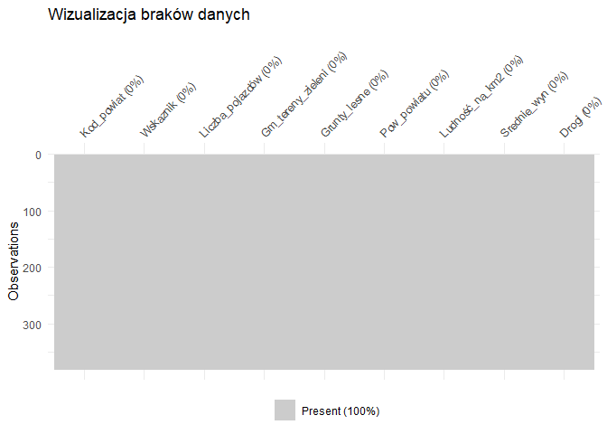

```r
# Wizualizacja braków danych
vis_miss(Dane) +
  labs(title = "Wizualizacja braków danych")
```

Analiza kompletności danych wykazała, że wszystkie zmienne zawarte w zbiorze są w pełni uzupełnione – nie występują żadne wartości brakujące. Zarówno ilościowe podsumowanie braków, jak i wizualizacja za pomocą funkcji vis_miss() potwierdzają 100% obecność danych we wszystkich kolumnach. Dzięki temu dane nie wymagają dodatkowego przygotowania w postaci imputacji czy usuwania obserwacji, co wzmacnia rzetelność dalszych analiz statystycznych i przestrzennych.

## Identyfikacja obserwacji odstających (OUTLIERS)

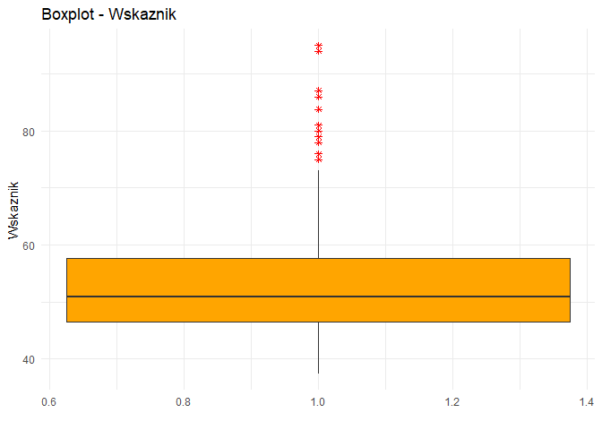

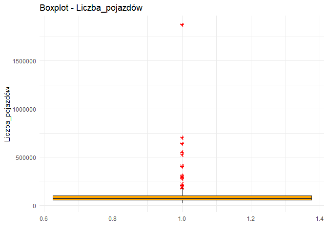

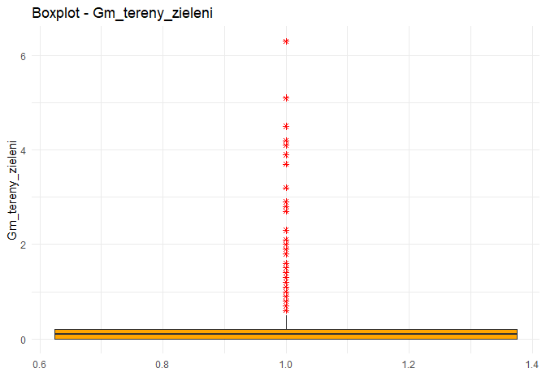

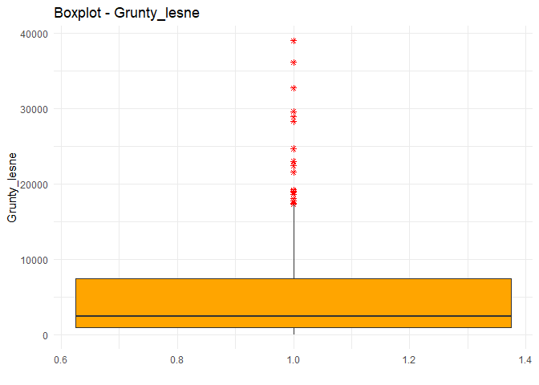

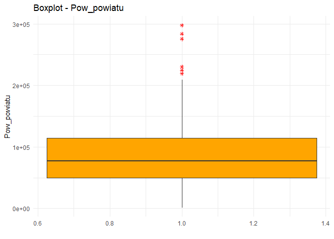

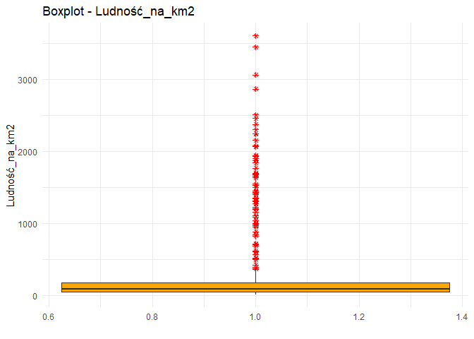

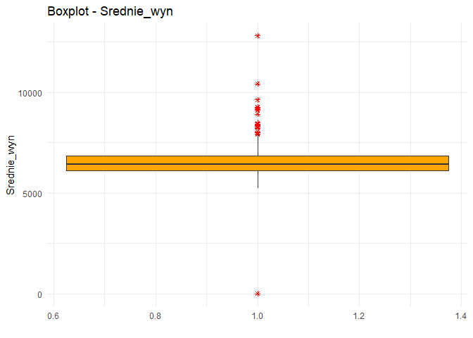

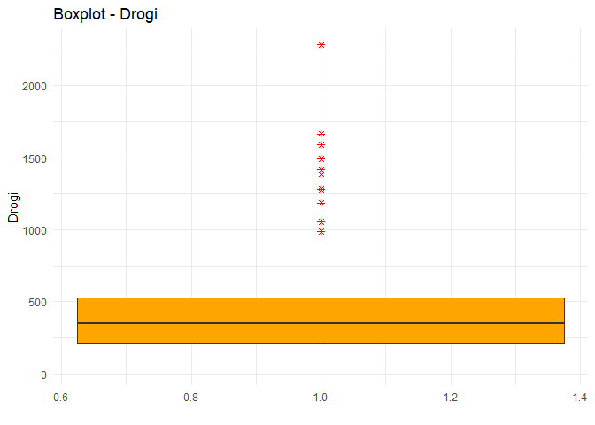

```
## [1] "Indeksy obserwacji odstających w poszczególnych zmiennych:"
```

```
## $Wskaznik
##  [1] 135 265 268 272 273 277 279 281 282 283 284 285 286 288 289 356
##
## $Liczba_pojazdów
##  [1]  29  50  62  76 113 121 131 135 158 170 179 231 250 251 274 279 293 345 359
## [20] 379
##
## $Gm_tereny_zieleni
##  [1]  27  28  29  30  50  51  52  53  74  75  76  77  90 113 114 115 135 136 137
## [20] 175 176 177 178 179 191 214 215 216 231 232 233 250 252 253 254 266 271 272
## [39] 273 274 275 276 277 278 279 280 281 282 283 284 285 286 287 288 289 303 323
## [58] 324 356 357 358 359 378 379
##
## $Grunty_lesne
##  [1]  54  55  73 122 124 125 126 130 140 152 163 166 169 218 219 223 226 229 270
## [20] 293
##
## $Pow_powiatu
## [1]  54 218 234 245 293 317
##
## $Ludność_na_km2
##  [1]  27  28  29  30  50  51  52  53  74  75  76  77  90  91 113 114 115 128 135
## [20] 136 137 158 175 176 177 178 179 191 213 214 215 216 231 232 233 250 251 252
## [39] 253 254 261 267 268 271 272 273 274 275 276 277 278 279 280 281 282 283 284
## [58] 285 286 287 288 289 303 323 324 356 357 358 359 378 379
##
## $Srednie_wyn
##  [1]  11  22  23  29  63  92 102 135 144 151 158 168 176 179 250 253 275 276 277
## [20] 278 279 359 379
##
## $Drogi
##  [1]  48  62 121 125 126 131 162 179 256 293 334 345
```

Na podstawie analizy zmiennych ilościowych za pomocą reguły IQR (interquartile range) zidentyfikowano obserwacje odstające w każdej z badanych zmiennych. W szczególności: Wskaźnik zanieczyszczenia wykazuje 16 wartości odstających, co może wskazywać na powiaty o skrajnie wysokim poziomie zanieczyszczenia, np. ze względu na działalność przemysłową. Liczba pojazdów oraz długość dróg to zmienne infrastrukturalne, w których odchylenia sugerują silną koncentrację transportu w wybranych lokalizacjach. Gęstość zaludnienia i średnie wynagrodzenie również charakteryzują się wieloma odchyleniami, co wskazuje na wyraźne różnice społeczno-ekonomiczne między powiatami. Duża liczba obserwacji odstających w zmiennych środowiskowych, takich jak tereny zieleni i grunty leśne, może wynikać z naturalnych różnic w pokryciu terenu (np. obszary miejskie vs. górskie i leśne). Obserwacje te nie muszą być błędami, lecz mogą wskazywać na istotne przypadki szczególne (np. powiaty o specyficznym charakterze). Zamiast je usuwać, warto rozważyć dalszą eksplorację tych jednostek terytorialnych jako potencjalnych klastrów analizy lub przypadków do pogłębionej interpretacji jakościowej.

# Statystyki opisowe

```r
# Wybór kolumn numerycznych
Dane_num <- Dane %>% select(where(is.numeric))

# Obliczanie statystyk opisowych
statystyki <- data.frame(
  Zmienna = names(Dane_num),
  Srednia = sapply(Dane_num, mean, na.rm = TRUE),
  Mediana = sapply(Dane_num, median, na.rm = TRUE),
  Minimum = sapply(Dane_num, min, na.rm = TRUE),
  Maksimum = sapply(Dane_num, max, na.rm = TRUE),
  Odchylenie_std = sapply(Dane_num, sd, na.rm = TRUE),
  Asymetria = sapply(Dane_num, skewness, na.rm = TRUE)
)

# Zaokrągl tylko kolumny numeryczne (bez kolumny "Zmienna")
statystyki[ , -1] <- round(statystyki[ , -1], 2)

# Wyświetlenie tabeli
print(statystyki[ , -1])
```

```
##                    Srednia  Mediana  Minimum   Maksimum Odchylenie_std
## Wskaznik             53.13    50.93    37.40      95.00           9.74
## Liczba_pojazdów   94514.43 71490.00 21125.00 1874318.00      117474.54
## Gm_tereny_zieleni     0.39     0.10     0.00       6.30           0.85
## Grunty_lesne       4937.43  2449.65     4.34   39014.33        6203.21
## Pow_powiatu       82613.52 77279.00  1330.00  297656.00       51883.51
## Ludność_na_km2      345.78    90.00    18.00    3600.00         612.35
## Srednie_wyn        6560.32  6415.45     0.00   12804.03         839.04
## Drogi               408.32   348.90    30.20    2281.70         286.37
##                   Asymetria
## Wskaznik               1.34
## Liczba_pojazdów       10.22
## Gm_tereny_zieleni      3.40
## Grunty_lesne           2.20
## Pow_powiatu            0.69
## Ludność_na_km2         2.57
## Srednie_wyn            0.87
## Drogi                  1.99
```

Podsumowując, większość zmiennych wykazuje silną asymetrię prawostronną oraz duże zróżnicowanie, co należy uwzględnić przy doborze metod statystycznych oraz interpretacji wyników regresji czy analiz przestrzennych.

```r
##Analiza korelacji między zmiennymi ilościowymi (wszystkimi)

# Wybór kolumn numerycznych
Dane_num <- Dane %>% select(where(is.numeric))

# Obliczanie macierzy korelacji (domyślnie metoda Pearsona)
macierz_korelacji <- cor(Dane_num, use = "complete.obs")

# Wyświetlenie macierzy korelacji
print(round(macierz_korelacji, 2))
```

```
##                   Wskaznik Liczba_pojazdów Gm_tereny_zieleni Grunty_lesne
## Wskaznik              1.00            0.26              0.57        -0.15
## Liczba_pojazdów       0.26            1.00              0.33         0.01
## Gm_tereny_zieleni     0.57            0.33              1.00        -0.28
## Grunty_lesne         -0.15            0.01             -0.28         1.00
## Pow_powiatu          -0.53           -0.04             -0.53         0.55
## Ludność_na_km2        0.63            0.45              0.87        -0.28
## Srednie_wyn           0.15            0.36              0.32        -0.20
## Drogi                 0.04            0.42             -0.21         0.49
##                   Pow_powiatu Ludność_na_km2 Srednie_wyn Drogi
## Wskaznik                -0.53           0.63        0.15  0.04
## Liczba_pojazdów         -0.04           0.45        0.36  0.42
## Gm_tereny_zieleni       -0.53           0.87        0.32 -0.21
## Grunty_lesne             0.55          -0.28       -0.20  0.49
## Pow_powiatu              1.00          -0.59       -0.25  0.41
## Ludność_na_km2          -0.59           1.00        0.34 -0.17
## Srednie_wyn             -0.25           0.34        1.00 -0.05
## Drogi                    0.41          -0.17       -0.05  1.00
```

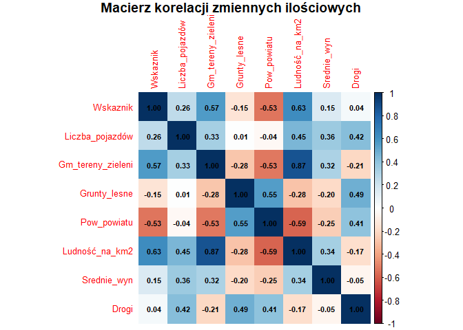

```r
# Wizualizacja korelacji
corrplot(macierz_korelacji, method = "color", addCoef.col = "black",
         tl.cex = 0.8, number.cex = 0.7,
         title = "Macierz korelacji zmiennych ilościowych",
         mar = c(0, 0, 1, 0))
```

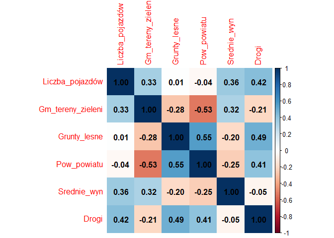

```r
# Analiza korelacji między zmiennymi ilościowymi (po dopasowaniu)

# Wybierz tylko kolumny numeryczne
num_cols <- sapply(Dane, is.numeric)

# Nazwy kolumn, które chcesz wykluczyć
kolumny_do_pominiecia <- c("Kod_powiat", "Wskaznik","Ludność_na_km2") #Korelacja tych zmeinnych była zbyt wysoka

# Usuń te kolumny z listy numerycznych
num_cols[names(num_cols) %in% kolumny_do_pominiecia] <- FALSE

# Oblicz macierz korelacji
corr_matrix <- cor(Dane[, num_cols])

# Obliczenie korelacji
corrplot(corr_matrix, method = "color", addCoef.col = "black")  # Wizualizacja
```

# Wizualizacja danych

## Histogramy tylko dla zmiennych ilościowych

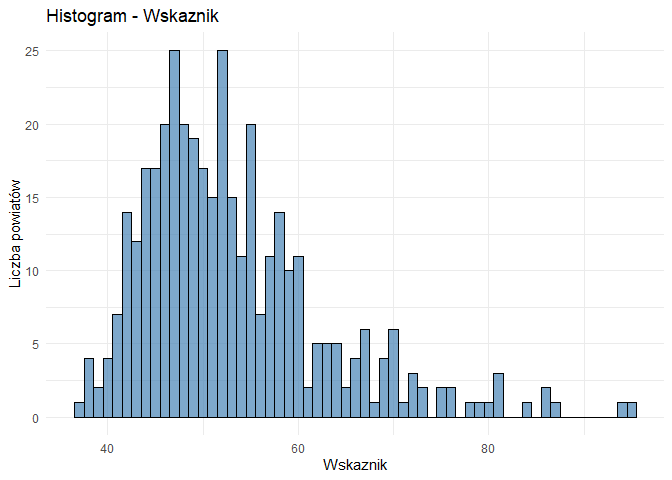

[figure not shown]

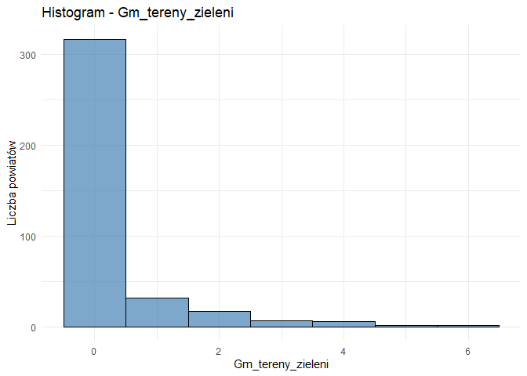

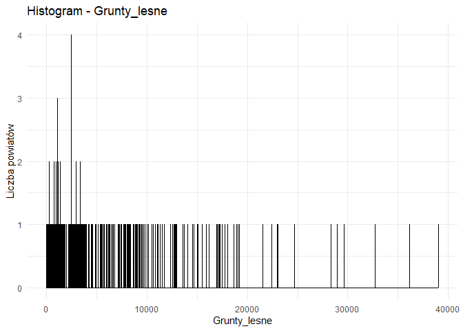

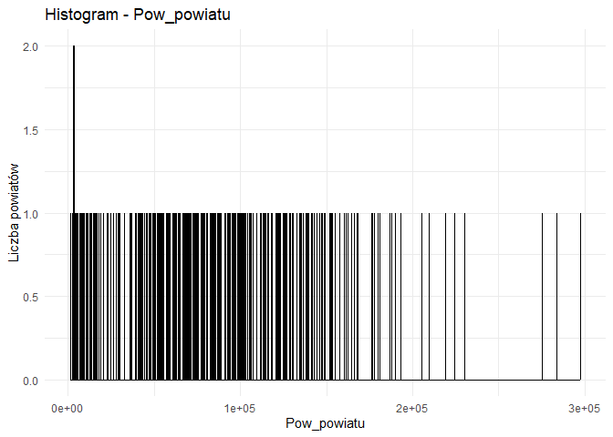

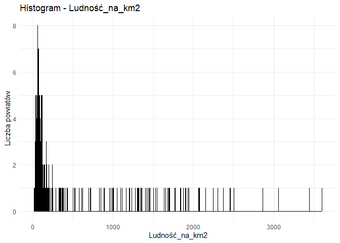

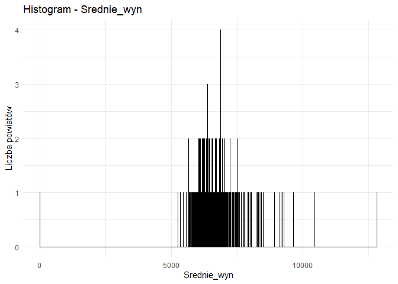

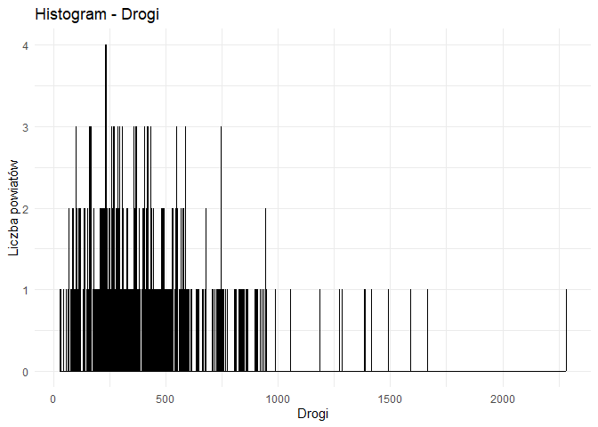

```r
Dane_num <- Dane %>% select(where(is.numeric))
# Histogramy tylko dla zmiennych ilościowych
for (zm in names(Dane_num)) {
  print(
    ggplot(Dane, aes(x = .data[[zm]])) +
      geom_histogram(binwidth = 1, fill = "steelblue", color = "black", alpha = 0.7) +
      labs(title = paste("Histogram -", zm),
           x = zm, y = "Liczba powiatów") +
      theme_minimal()
  )
}
```

Większość zmiennych wykazuje **silną asymetrię prawostronną**, co oznacza, że znaczna liczba powiatów ma niskie wartości, a tylko nieliczne – bardzo wysokie.

- **Wskaźnik zanieczyszczenia** ma rozkład lekko skośny, z większością wartości między 45 a 60. Rozkład ten jest umiarkowanie symetryczny z kilkoma wartościami odstającymi.
- **Tereny zieleni (Gm_tereny_zieleni)** i **lasy (Grunty_lesne)** są skoncentrowane w nielicznych powiatach – większość z nich ma bardzo niskie wartości.
- **Powierzchnia powiatów**, **ludność na km²** i **długość dróg** pokazują bardzo rozciągnięte ogony – wskazuje to na obecność kilku dużych, silnie zurbanizowanych jednostek (np. miasta wojewódzkie).
- **Średnie wynagrodzenie** również ma rozkład niesymetryczny – większość wartości oscyluje wokół średniego poziomu, z pojedynczymi powiatami o bardzo wysokich płacach.

## Wykresy gęstości dla zmiennych numerycznych

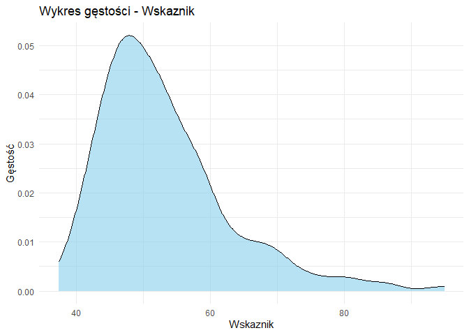

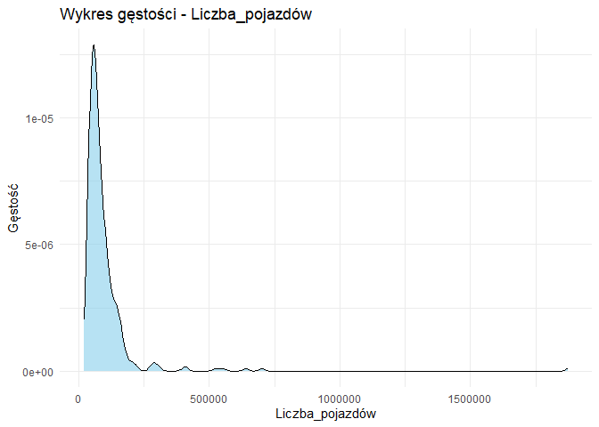

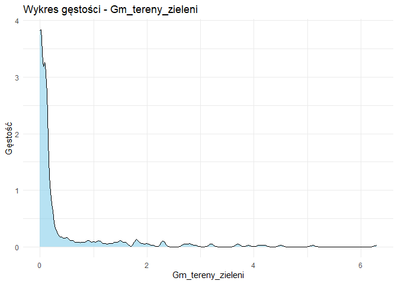

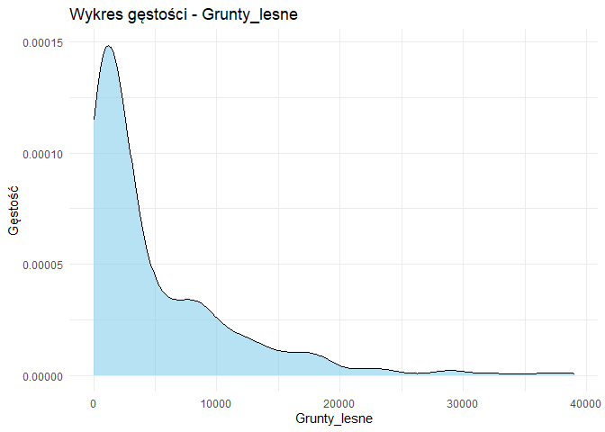

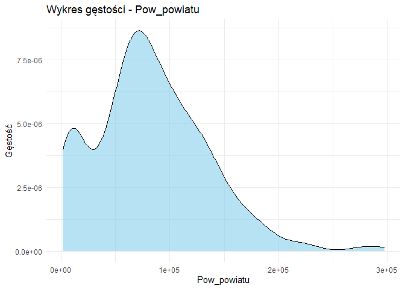

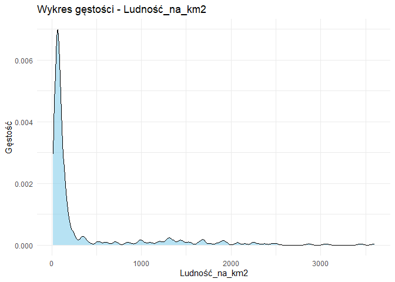

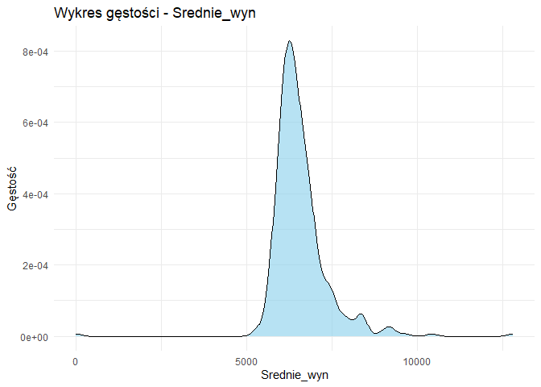

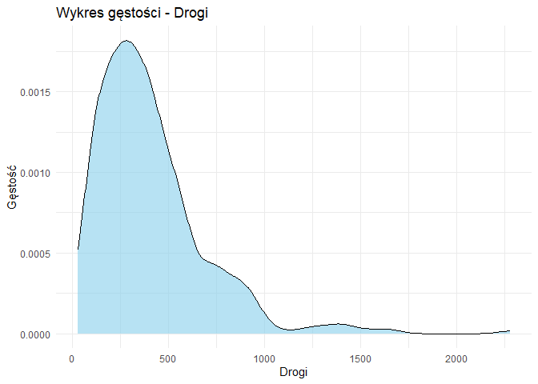

```r
for (zm in names(Dane_num)) {
  print(
    ggplot(Dane, aes_string(x = zm)) +
      geom_density(fill = "skyblue", alpha = 0.6) +
      labs(title = paste("Wykres gęstości -", zm),
           x = zm, y = "Gęstość") +
      theme_minimal()
  )
}
```

Rozkłady zmiennych ilościowych są w większości **asymetryczne prawostronnie**, co oznacza, że większość powiatów ma niskie wartości, a tylko nieliczne znacznie wyższe (np. liczba pojazdów, powierzchnia, długość dróg). Dotyczy to również zmiennych środowiskowych, jak **tereny zieleni** i **grunty leśne**, których większość powiatów posiada niewiele.

Rozkład **wskaźnika zanieczyszczenia** jest bardziej zbliżony do normalnego, z lekką asymetrią. Tylko **średnie wynagrodzenie** prezentuje bardziej symetryczny i skupiony rozkład.

Potwierdzenie podobnego kształtu przez histogramy i wykresy gęstości wzmacnia wiarygodność obserwacji dotyczących asymetrii i wartości odstających.

## Wykresy Rozrzutu – relacja względem zmiennej Wskaznik

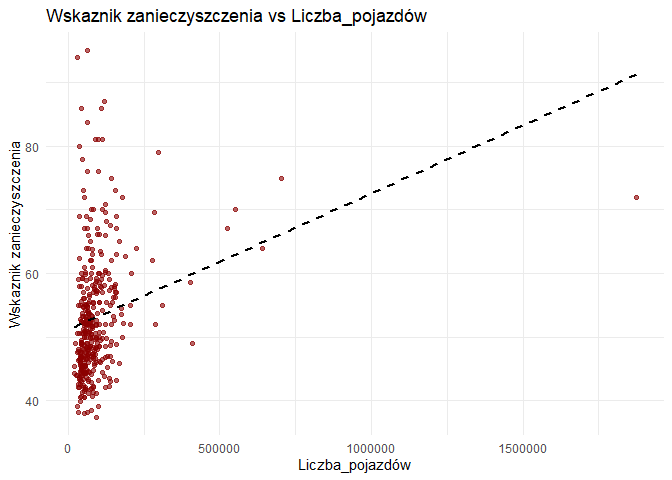

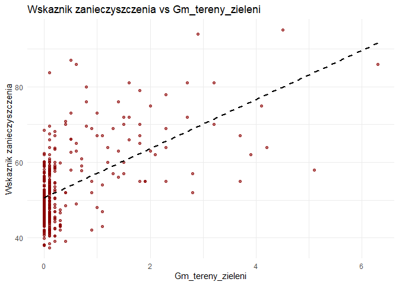

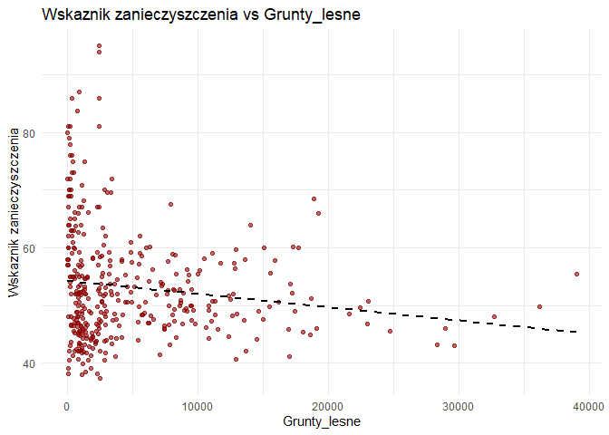

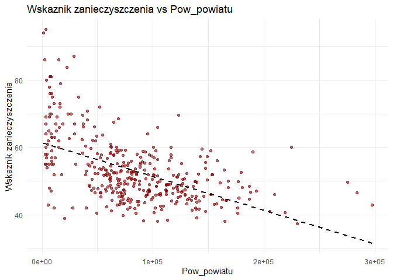

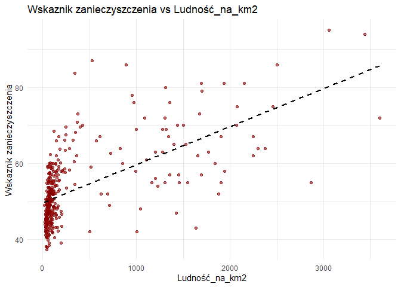

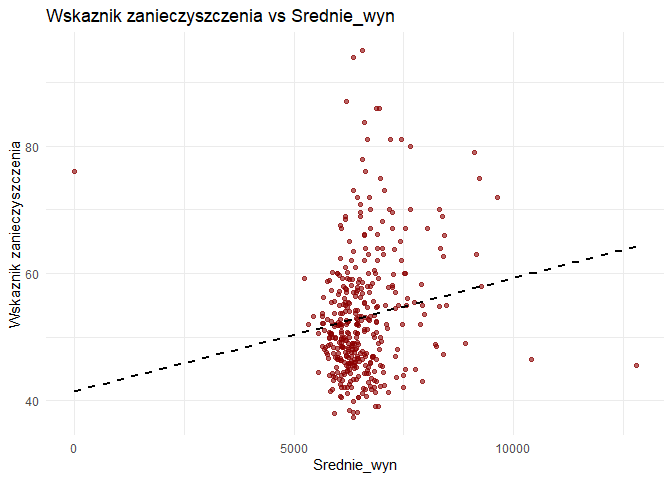

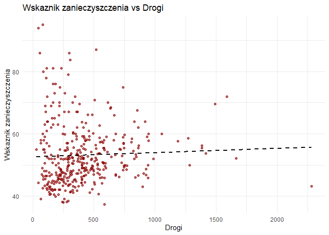

```r
#Lista zmiennych, które mogą wpływać na zanieczyszczenie
zmienne_x <- c("Liczba_pojazdów", "Gm_tereny_zieleni", "Grunty_lesne",
               "Pow_powiatu", "Ludność_na_km2", "Srednie_wyn", "Drogi")

for (zm in zmienne_x) {
  print(
    ggplot(Dane, aes_string(x = zm, y = "Wskaznik")) +
      geom_point(color = "darkred", alpha = 0.6) +
      geom_smooth(method = "lm", se = FALSE, color = "black", linetype = "dashed") +
      labs(title = paste("Wskaznik zanieczyszczenia vs", zm),
           x = zm, y = "Wskaznik zanieczyszczenia") +
      theme_minimal()
  )
}
```

Widoczne rozproszenie punktów i obecność wartości odstających wskazują, że relacje te są istotne, ale niejednorodne – wymagają dalszego modelowania, np. regresji wielorakiej lub przestrzennej.

## Kartogramy zmiennych objaśniających

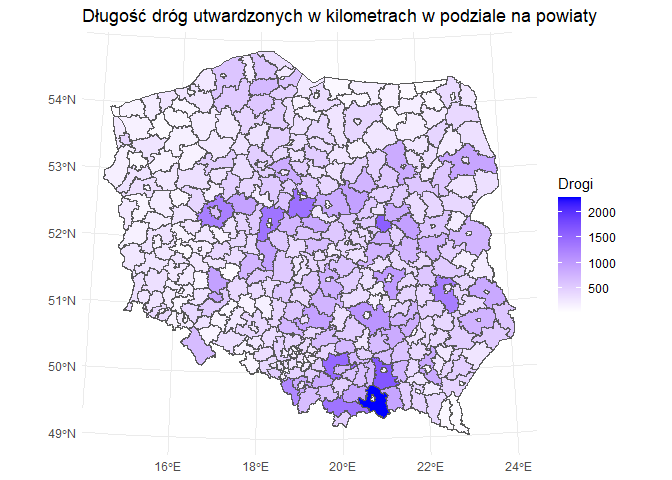

```r
colnames(Dane) <- c("Kod_powiat", "Wskaznik", "Liczba_pojazdów",
                    "Gm_tereny_zieleni", "Grunty_lesne", "Pow_powiatu",
                    "Ludność_na_km2", "Srednie_wyn", "Drogi")

# Upewnij się, że kod powiatu jest typu character
Dane$Kod_powiat <- as.character(Dane$Kod_powiat)
mapa$JPT_KOD_JE <- as.character(mapa$JPT_KOD_JE)

# Połącz dane
mapa_dane <- merge(mapa, Dane, by.x = "JPT_KOD_JE", by.y = "Kod_powiat")
#Kartogram Dróg
ggplot(data = mapa_dane) +
  geom_sf(aes(fill = Drogi)) +
  scale_fill_gradient(low = "White", high = "blue") +
  labs(title = "Długość dróg utwardzonych w kilometrach w podziale na powiaty") +
  theme_minimal()
```

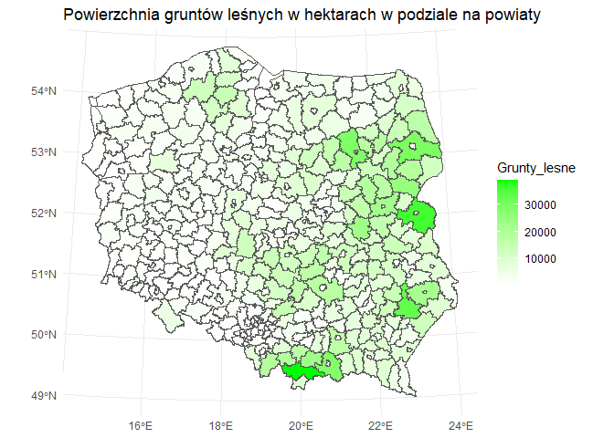

```r
#Kartogram Gruntów leśnych
ggplot(data = mapa_dane) +
  geom_sf(aes(fill = Grunty_lesne)) +
  scale_fill_gradient(low = "White", high = "green") +
  labs(title = "Powierzchnia gruntów leśnych w hektarach w podziale na powiaty") +
  theme_minimal()
```

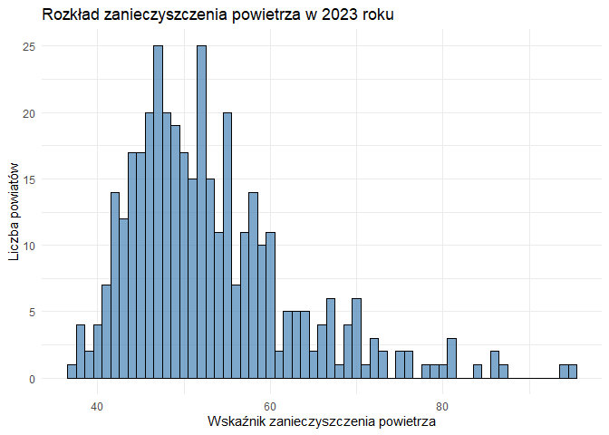

```r
#Histogram zanieczyszczenia powietrza w 2023 roku
ggplot(Dane, aes(x = Wskaznik)) +
  geom_histogram(binwidth = 1, fill = "steelblue", color = "black", alpha = 0.7) +
  labs(
    title = "Rozkład zanieczyszczenia powietrza w 2023 roku",
    x = "Wskaźnik zanieczyszczenia powietrza",
    y = "Liczba powiatów"
  ) +
  theme_minimal()
```

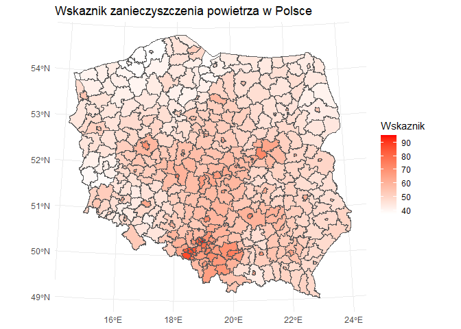

```r
ggplot(data = mapa_dane) +
  geom_sf(aes(fill = Wskaznik)) +
  scale_fill_gradient(low = "White", high = "red") +
  labs(title = "Wskaznik zanieczyszczenia powietrza w Polsce") +
  theme_minimal()
```

### Kartogramy – interpretacja

Rozkłady te wskazują na potencjalną zależność między środowiskiem, infrastrukturą a zanieczyszczeniem – co potwierdzają wcześniejsze analizy korelacyjne i regresyjne.

# Analiza przestrzenna

```r
##Identyfikacja przestrzennych skupisk i obserwacji odstających (hot/cold spots)
# Moran I test
moran.test(Dane$Wskaznik, lw)
```

```
##
##  Moran I test under randomisation
##
## data:  Dane$Wskaznik
## weights: lw
##
## Moran I statistic standard deviate = 21.693, p-value < 2.2e-16
## alternative hypothesis: greater
## sample estimates:
## Moran I statistic       Expectation          Variance
##       0.733864665      -0.002638522       0.001152646
```

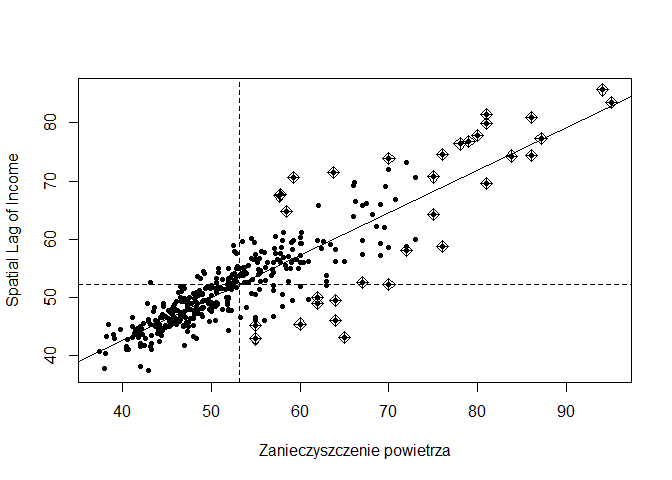

```r
#Moran Plot
moran.plot(Dane$Wskaznik, lw, labels = FALSE, pch = 20,
           xlab = "Zanieczyszczenie powietrza",
           ylab = "Spatial Lag of Income")
```

```r
local_moran <- localmoran(Dane$Wskaznik, lw)

# Obliczenie lokalnych statystyk Morana
local_moran <- localmoran(mapa_dane$Wskaznik, lw, zero.policy = TRUE)

# Dołączenie wyników do ramki danych
mapa_dane$Ii <- local_moran[, 1]       # lokalny wskaźnik Morana
mapa_dane$E.Ii <- local_moran[, 2]     # wartość oczekiwana
mapa_dane$Var.Ii <- local_moran[, 3]   # wariancja
mapa_dane$Z.Ii <- local_moran[, 4]     # statystyka Z
mapa_dane$P.Ii <- local_moran[, 5]     # p-wartość

# Klasyfikacja skupisk
mapa_dane <- mapa_dane %>%
  mutate(
    klaster = case_when(
      Z.Ii > 1.96 & Wskaznik > mean(Wskaznik, na.rm = TRUE) ~ "Hot Spot",
      Z.Ii > 1.96 & Wskaznik < mean(Wskaznik, na.rm = TRUE) ~ "Cold Spot",
      Z.Ii < -1.96                                           ~ "Outlier",
      TRUE                                                   ~ "Brak istotności"
    )
  )

# Zamiana na factor dla lepszej kolejności w legendzie
mapa_dane$klaster <- factor(mapa_dane$klaster,
                            levels = c("Hot Spot", "Cold Spot", "Outlier", "Brak istotności"))
```

Wartość statystyki Morana I wynosi **0.73** przy bardzo niskim poziomie istotności (*p* < 2.2e-16), co jednoznacznie wskazuje na **silną i istotną przestrzenną autokorelację** wskaźnika zanieczyszczenia powietrza. Oznacza to, że powiaty o podobnym poziomie zanieczyszczenia tworzą przestrzenne klastry – sąsiadujące jednostki mają zbliżone wartości.

Wykres Morana (scatterplot) potwierdza ten wynik: dane dobrze układają się wzdłuż rosnącej linii regresji, szczególnie w prawym górnym i lewym dolnym ćwiartku, co oznacza obecność **hot i cold spotów** – skupisk wysokich i niskich wartości.

## Mapa klastrów (hot/cold spots)

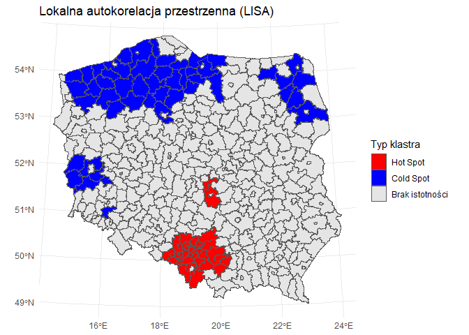

```r
ggplot(data = mapa_dane) +
  geom_sf(aes(fill = klaster)) +
  scale_fill_manual(values = c("Hot Spot" = "red",
                               "Cold Spot" = "blue",
                               "Outlier" = "orange",
                               "Brak istotności" = "grey90")) +
  labs(title = "Lokalna autokorelacja przestrzenna (LISA)",
       fill = "Typ klastra") +
  theme_minimal()
```

Analiza lokalnej autokorelacji przestrzennej (LISA) ujawnia wyraźne **klastry zanieczyszczenia powietrza**:

- **Hot spoty** (na czerwono) zlokalizowane są głównie na południu Polski, w tym na Śląsku – obszarze o wysokim uprzemysłowieniu i gęstej zabudowie.
- **Cold spoty** (na niebiesko) występują głównie w północnej i północno-wschodniej Polsce, co wskazuje na większy udział terenów zielonych i niższą gęstość zaludnienia.
- Większość powiatów (na szaro) nie wykazuje istotnej lokalnej autokorelacji, co sugeruje zróżnicowanie wewnętrzne lub brak wyraźnych sąsiednich zależności.

Mapa potwierdza istnienie przestrzennych wzorców zanieczyszczenia, które powinny być uwzględniane w politykach regionalnych.

```r
#Pomocniczy model liniowy
model_stat <- lm(
  Wskaznik ~ Liczba_pojazdów +
    Gm_tereny_zieleni +
    Grunty_lesne +
    Pow_powiatu +
    Ludność_na_km2 +
    Srednie_wyn +
    Drogi,
  data = Dane)

summary(model_stat)
```

```
##
## Call:
## lm(formula = Wskaznik ~ Liczba_pojazdów + Gm_tereny_zieleni +
##     Grunty_lesne + Pow_powiatu + Ludność_na_km2 + Srednie_wyn +
##     Drogi, data = Dane)
##
## Residuals:
##      Min       1Q   Median       3Q      Max
## -24.9542  -3.6794  -0.4726   3.9080  27.7938
##
## Coefficients:
##                     Estimate Std. Error t value Pr(>|t|)
## (Intercept)        5.727e+01  3.273e+00  17.495  < 2e-16 ***
## Liczba_pojazdów   -7.948e-06  4.432e-06  -1.793   0.0737 .
## Gm_tereny_zieleni  1.278e+00  8.531e-01   1.498   0.1350
## Grunty_lesne       1.069e-04  7.404e-05   1.444   0.1495
## Pow_powiatu       -7.575e-05  1.008e-05  -7.517 4.23e-13 ***
## Ludność_na_km2     6.874e-03  1.372e-03   5.010 8.45e-07 ***
## Srednie_wyn       -7.302e-04  4.714e-04  -1.549   0.1222
## Drogi              1.042e-02  1.714e-03   6.080 2.98e-09 ***
## ---
## Signif. codes:  0 '***' 0.001 '**' 0.01 '*' 0.05 '.' 0.1 ' ' 1
##
## Residual standard error: 6.83 on 372 degrees of freedom
## Multiple R-squared:  0.5179, Adjusted R-squared:  0.5088
## F-statistic: 57.09 on 7 and 372 DF,  p-value: < 2.2e-16
```

```r
model_best_stat <- step(model_stat, direction = "backward")
```

```
## Start:  AIC=1468.08
## Wskaznik ~ Liczba_pojazdów + Gm_tereny_zieleni + Grunty_lesne +
##     Pow_powiatu + Ludność_na_km2 + Srednie_wyn + Drogi
##
##                     Df Sum of Sq   RSS    AIC
## <none>                           17351 1468.1
## - Grunty_lesne       1     97.28 17449 1468.2
## - Gm_tereny_zieleni  1    104.68 17456 1468.4
## - Srednie_wyn        1    111.93 17463 1468.5
## - Liczba_pojazdów    1    150.00 17501 1469.3
## - Ludność_na_km2     1   1170.56 18522 1490.9
## - Drogi              1   1724.25 19076 1502.1
## - Pow_powiatu        1   2635.50 19987 1519.8
```

```r
summary(model_best_stat)
```

```
##
## Call:
## lm(formula = Wskaznik ~ Liczba_pojazdów + Gm_tereny_zieleni +
##     Grunty_lesne + Pow_powiatu + Ludność_na_km2 + Srednie_wyn +
##     Drogi, data = Dane)
##
## Residuals:
##      Min       1Q   Median       3Q      Max
## -24.9542  -3.6794  -0.4726   3.9080  27.7938
##
## Coefficients:
##                     Estimate Std. Error t value Pr(>|t|)
## (Intercept)        5.727e+01  3.273e+00  17.495  < 2e-16 ***
## Liczba_pojazdów   -7.948e-06  4.432e-06  -1.793   0.0737 .
## Gm_tereny_zieleni  1.278e+00  8.531e-01   1.498   0.1350
## Grunty_lesne       1.069e-04  7.404e-05   1.444   0.1495
## Pow_powiatu       -7.575e-05  1.008e-05  -7.517 4.23e-13 ***
## Ludność_na_km2     6.874e-03  1.372e-03   5.010 8.45e-07 ***
## Srednie_wyn       -7.302e-04  4.714e-04  -1.549   0.1222
## Drogi              1.042e-02  1.714e-03   6.080 2.98e-09 ***
## ---
## Signif. codes:  0 '***' 0.001 '**' 0.01 '*' 0.05 '.' 0.1 ' ' 1
##
## Residual standard error: 6.83 on 372 degrees of freedom
## Multiple R-squared:  0.5179, Adjusted R-squared:  0.5088
## F-statistic: 57.09 on 7 and 372 DF,  p-value: < 2.2e-16
```

```r
#standaryzowanie danych
Dane_std <- Dane %>% mutate(across(where(is.numeric), scale))
print(Dane_std)
```

```
## # A tibble: 380 × 9
##    Kod_powiat Wskaznik[,1] Liczba_pojazdów[,1] Gm_tereny_zieleni[,1]
##    <chr>             <dbl>               <dbl>                 <dbl>
##  1 0201            -0.0816              -0.176                -0.342
##  2 0202            -0.673               -0.104                -0.106
##  3 0203            -0.595               -0.242                -0.106
##  4 0204            -0.706               -0.510                -0.460
##  5 0205            -1.11                -0.378                -0.224
##  6 0206            -0.902               -0.345                -0.342
##  7 0207            -1.14                -0.520                -0.342
##  8 0208             0.0162               0.460                -0.342
##  9 0209            -0.321               -0.357                -0.342
## 10 0210             0.148               -0.370                -0.342
## # ℹ 370 more rows
## # ℹ 5 more variables: Grunty_lesne <dbl[,1]>, Pow_powiatu <dbl[,1]>,
## #   Ludność_na_km2 <dbl[,1]>, Srednie_wyn <dbl[,1]>, Drogi <dbl[,1]>
```

```r
# Połączenie danych z mapą
mapa_dane_std <- mapa %>%
  left_join(Dane_std, by = c("JPT_KOD_JE" = "Kod_powiat"))
```

# Modelowanie ekonometryczne i ocena modelu

```r
# Klasyczny model liniowy OLS
model_ols <- lm(Wskaznik ~ Liczba_pojazdów +
                  Gm_tereny_zieleni +
                  Grunty_lesne +
                  Pow_powiatu +
                  Ludność_na_km2 +
                  Srednie_wyn +
                  Drogi,
                data = Dane_std)

res_squared <- residuals(model_ols)^2
moran.test(res_squared, lw)
```

```
##
##  Moran I test under randomisation
##
## data:  res_squared
## weights: lw
##
## Moran I statistic standard deviate = 10.557, p-value < 2.2e-16
## alternative hypothesis: greater
## sample estimates:
## Moran I statistic       Expectation          Variance
##       0.342511554      -0.002638522       0.001068803
```

```r
# Podsumowanie wyników
summary(model_ols)
```

```
##
## Call:
## lm(formula = Wskaznik ~ Liczba_pojazdów + Gm_tereny_zieleni +
##     Grunty_lesne + Pow_powiatu + Ludność_na_km2 + Srednie_wyn +
##     Drogi, data = Dane_std)
##
## Residuals:
##      Min       1Q   Median       3Q      Max
## -2.56072 -0.37756 -0.04849  0.40102  2.85211
##
## Coefficients:
##                     Estimate Std. Error t value Pr(>|t|)
## (Intercept)       -2.238e-16  3.595e-02   0.000   1.0000
## Liczba_pojazdów   -9.582e-02  5.343e-02  -1.793   0.0737 .
## Gm_tereny_zieleni  1.111e-01  7.416e-02   1.498   0.1350
## Grunty_lesne       6.807e-02  4.713e-02   1.444   0.1495
## Pow_powiatu       -4.033e-01  5.365e-02  -7.517 4.23e-13 ***
## Ludność_na_km2     4.319e-01  8.622e-02   5.010 8.45e-07 ***
## Srednie_wyn       -6.287e-02  4.058e-02  -1.549   0.1222
## Drogi              3.062e-01  5.036e-02   6.080 2.98e-09 ***
## ---
## Signif. codes:  0 '***' 0.001 '**' 0.01 '*' 0.05 '.' 0.1 ' ' 1
##
## Residual standard error: 0.7008 on 372 degrees of freedom
## Multiple R-squared:  0.5179, Adjusted R-squared:  0.5088
## F-statistic: 57.09 on 7 and 372 DF,  p-value: < 2.2e-16
```

```r
# Spatial lag model (SAR)
#Model SAR
model_sar <- lagsarlm(Wskaznik ~ Liczba_pojazdów +
                        Gm_tereny_zieleni +
                        Grunty_lesne +
                        Pow_powiatu +
                        Ludność_na_km2 +
                        Srednie_wyn +
                        Drogi,
                      data = mapa_dane_std,listw = lw, method = "eigen", zero.policy = TRUE)

# Podsumowanie wyników
summary(model_sar)
```

```
##
## Call:lagsarlm(formula = Wskaznik ~ Liczba_pojazdów + Gm_tereny_zieleni +
##     Grunty_lesne + Pow_powiatu + Ludność_na_km2 + Srednie_wyn +
##     Drogi, data = mapa_dane_std, listw = lw, method = "eigen",
##     zero.policy = TRUE)
##
## Residuals:
##       Min        1Q    Median        3Q       Max
## -1.142568 -0.186299 -0.023356  0.176798  1.220844
##
## Type: lag
## Coefficients: (asymptotic standard errors)
##                    Estimate Std. Error z value  Pr(>|z|)
## (Intercept)        0.077200   0.017311  4.4595 8.214e-06
## Liczba_pojazdów   -0.016513   0.025948 -0.6364 0.5245117
## Gm_tereny_zieleni -0.051163   0.035834 -1.4278 0.1533522
## Grunty_lesne       0.006162   0.022690  0.2716 0.7859466
## Pow_powiatu       -0.091473   0.026706 -3.4252 0.0006144
## Ludność_na_km2     0.410556   0.041604  9.8682 < 2.2e-16
## Srednie_wyn       -0.034431   0.019519 -1.7640 0.0777316
## Drogi              0.047296   0.025244  1.8735 0.0609950
##
## Rho: 0.80325, LR test value: 484.12, p-value: < 2.22e-16
## Asymptotic standard error: 0.02118
##     z-value: 37.924, p-value: < 2.22e-16
## Wald statistic: 1438.3, p-value: < 2.22e-16
##
## Log likelihood: -158.0098 for lag model
## ML residual variance (sigma squared): 0.11357, (sigma: 0.337)
## Number of observations: 380
## Number of parameters estimated: 10
## AIC: 336.02, (AIC for lm: 818.14)
## LM test for residual autocorrelation
## test value: 5.0144, p-value: 0.025137
```

```r
res_squared1 <- residuals(model_sar)^2
moran.test(res_squared1, lw)
```

```
##
##  Moran I test under randomisation
##
## data:  res_squared1
## weights: lw
##
## Moran I statistic standard deviate = 7.0816, p-value = 7.126e-13
## alternative hypothesis: greater
## sample estimates:
## Moran I statistic       Expectation          Variance
##       0.233157637      -0.002638522       0.001108697
```

Początkowy model liniowy wykazywał dobrą dopasowalność (R² ≈ 0.52), jednak test Morana I dla reszt (I = 0.34, *p* < 2.2e‑16) ujawnił **istotną przestrzenną autokorelację**, co oznacza, że klasyczna regresja niedoszacowuje wpływu zależności przestrzennych między powiatami. W odpowiedzi zastosowano przestrzenny model SAR (lagowy), który znacząco poprawił dopasowanie: wartość log-likelihood wzrosła, a AIC spadło z 818 do 336, co potwierdza wyższość modelu przestrzennego.

W modelu SAR współczynnik rho wynoszący 0.80 (istotny statystycznie) wskazuje na silny przestrzenny efekt zależności między powiatami – poziom zanieczyszczenia w jednym powiecie jest silnie powiązany ze średnią w otoczeniu. Kluczowe zmienne, takie jak **gęstość zaludnienia** i **powierzchnia powiatu**, pozostały istotne, natomiast znaczenie innych predyktorów (np. liczby pojazdów, dróg) osłabło po uwzględnieniu zależności przestrzennej.

Ostatecznie, także reszty z modelu SAR wykazują słabszą autokorelację (Moran I = 0.23), co świadczy o lepszym uchwyceniu struktury danych. Model SAR można uznać za trafniejsze narzędzie analizy regionalnych różnic w zanieczyszczeniu powietrza.

## Model SEM

```r
sem_model <- spautolm(
  formula = Wskaznik ~ Liczba_pojazdów + Pow_powiatu + Ludność_na_km2 + Drogi,
  data = Dane_std,
  listw = lw,  # lub "b" w nowszych wersjach
  method = "eigen"
)
summary(sem_model)
```

```
##
## Call: spautolm(formula = Wskaznik ~ Liczba_pojazdów + Pow_powiatu +
##     Ludność_na_km2 + Drogi, data = Dane_std, listw = lw, method = "eigen")
##
## Residuals:
##      Min       1Q   Median       3Q      Max
## -0.79150 -0.19493 -0.03304  0.15692  1.27682
##
## Coefficients:
##                   Estimate Std. Error z value Pr(>|z|)
## (Intercept)      0.0321753  0.2625946  0.1225  0.90248
## Liczba_pojazdów -0.0601730  0.0247191 -2.4343  0.01492
## Pow_powiatu      0.0245073  0.0266622  0.9192  0.35800
## Ludność_na_km2   0.4430950  0.0327530 13.5284  < 2e-16
## Drogi           -0.0077158  0.0247355 -0.3119  0.75509
##
## Lambda: 0.93295 LR test value: 469.9 p-value: < 2.22e-16
## Numerical Hessian standard error of lambda: 0.017952
##
## Log likelihood: -168.3819
## ML residual variance (sigma squared): 0.10818, (sigma: 0.32891)
## Number of observations: 380
## Number of parameters estimated: 7
## AIC: 350.76
```

```r
res_squared2 <- residuals(sem_model)^2
moran.test(res_squared2, lw)
```

```
##
##  Moran I test under randomisation
##
## data:  res_squared2
## weights: lw
##
## Moran I statistic standard deviate = 6.3017, p-value = 1.472e-10
## alternative hypothesis: greater
## sample estimates:
## Moran I statistic       Expectation          Variance
##       0.205775536      -0.002638522       0.001093796
```

Wśród zmiennych objaśniających tylko **ludność na km²** (*p* < 2e‑16) i w mniejszym stopniu **liczba pojazdów** (*p* ≈ 0.015) wykazują istotny wpływ. Natomiast **powierzchnia powiatu** i **długość dróg** nie są statystycznie znaczące po uwzględnieniu zależności przestrzennych.

## Przestrzenny Model Durbina (SDM)

```r
sdm_model <- lagsarlm(
  formula = Wskaznik ~ Liczba_pojazdów +
    Pow_powiatu +
    Ludność_na_km2 +
    Drogi,
    data = Dane_std,
  listw = lw,
  Durbin = TRUE
)

summary(sdm_model)
```

```
##
## Call:lagsarlm(formula = Wskaznik ~ Liczba_pojazdów + Pow_powiatu +
##     Ludność_na_km2 + Drogi, data = Dane_std, listw = lw, Durbin = TRUE)
##
## Residuals:
##       Min        1Q    Median        3Q       Max
## -1.035137 -0.200038 -0.016297  0.178699  1.269908
##
## Type: mixed
## Coefficients: (asymptotic standard errors)
##                      Estimate Std. Error z value  Pr(>|z|)
## (Intercept)          0.040883   0.020057  2.0384  0.041509
## Liczba_pojazdów     -0.046804   0.025835 -1.8117  0.070037
## Pow_powiatu         -0.021513   0.028605 -0.7521  0.451998
## Ludność_na_km2       0.419540   0.033027 12.7028 < 2.2e-16
## Drogi                0.013649   0.026785  0.5096  0.610350
## lag.Liczba_pojazdów  0.031304   0.044197  0.7083  0.478768
## lag.Pow_powiatu     -0.072388   0.034743 -2.0835  0.037202
## lag.Ludność_na_km2  -0.205120   0.067172 -3.0537  0.002261
## lag.Drogi            0.069231   0.029937  2.3125  0.020748
##
## Rho: 0.84412, LR test value: 347.08, p-value: < 2.22e-16
## Asymptotic standard error: 0.02783
##     z-value: 30.331, p-value: < 2.22e-16
## Wald statistic: 919.98, p-value: < 2.22e-16
##
## Log likelihood: -150.0565 for mixed model
## ML residual variance (sigma squared): 0.1061, (sigma: 0.32573)
## Number of observations: 380
## Number of parameters estimated: 11
## AIC: 322.11, (AIC for lm: 667.19)
## LM test for residual autocorrelation
## test value: 1.8766, p-value: 0.17072
```

```r
res_squared3 <- residuals(sdm_model)^2
moran.test(res_squared3, lw)
```

```
##
##  Moran I test under randomisation
##
## data:  res_squared3
## weights: lw
##
## Moran I statistic standard deviate = 6.6705, p-value = 1.274e-11
## alternative hypothesis: greater
## sample estimates:
## Moran I statistic       Expectation          Variance
##       0.218166821      -0.002638522       0.001095713
```

Model SAR z komponentem Durbin (efekty sąsiedztwa w zmiennych niezależnych) charakteryzuje się bardzo dobrym dopasowaniem (AIC = 322, log-likelihood = –150), znacznie lepszym niż klasyczna regresja liniowa (AIC = 667). Współczynnik rho = 0.84 (istotny przy *p* < 2.2e-16) potwierdza silną autokorelację przestrzenną w poziomie zanieczyszczenia.

Model Durbin lepiej oddaje złożoną zależność przestrzenną, gdzie nie tylko lokalne, ale też sąsiednie warunki mają wpływ na jakość powietrza. Test Morana I dla reszt wskazuje, że choć pewna autokorelacja pozostaje (*I* ≈ 0.22), to została znacznie zredukowana względem modelu klasycznego.

**Podsumowanie**

Zastosowanie metod ekonometrii przestrzennej w analizie zanieczyszczenia powietrza było uzasadnione charakterem badanego zjawiska. Przeprowadzone testy autokorelacji przestrzennej, w tym test Morana I, potwierdziły istnienie istotnych statystycznie zależności przestrzennych w rozkładzie wskaźnika zanieczyszczeń.

Wykorzystanie różnych specyfikacji modeli przestrzennych (SLX, SEM, SAR, SDM) pozwoliło na kompleksową analizę mechanizmów przestrzennego oddziaływania. Model SLX (Spatial Lag of X) uwzględnia przestrzenne opóźnienia zmiennych objaśniających, co jest szczególnie istotne w kontekście efektów spillover infrastruktury drogowej czy emisji z sąsiednich powiatów (Feng et al., 2020). Model SEM (Spatial Error Model) kontroluje przestrzenną autokorelację w składniku losowym, która może wynikać z pominiętych zmiennych o charakterze przestrzennym. Model SAR (Spatial Autoregressive) bezpośrednio modeluje wpływ poziomu zanieczyszczeń w sąsiednich powiatach, co odzwierciedla procesy dyfuzji zanieczyszczeń. Najbardziej kompleksowy model SDM (Spatial Durbin Model) łączy elementy SAR i SLX, umożliwiając jednoczesną analizę efektów bezpośrednich, pośrednich i całkowitych (Elhorst, 2014).

## Model SLX (Spatial Lag of X)

```r
slx_model <- lmSLX(
  formula = Wskaznik ~ Liczba_pojazdów +
    Pow_powiatu +
    Ludność_na_km2 +
    Drogi,
  data = Dane_std,
  listw = lw
)

summary(slx_model)
```

```
##
## Call:
## lm(formula = formula(paste("y ~ ", paste(colnames(x)[-1], collapse = "+"))),
##     data = as.data.frame(x), weights = weights)
##
## Coefficients:
##                      Estimate    Std. Error  t value     Pr(>|t|)
## (Intercept)           1.905e-01   3.409e-02   5.588e+00   4.447e-08
## Liczba_pojazdów      -4.121e-02   4.551e-02  -9.053e-01   3.659e-01
## Pow_powiatu          -1.711e-01   4.977e-02  -3.437e+00   6.554e-04
## Ludność_na_km2        3.997e-01   5.817e-02   6.870e+00   2.718e-11
## Drogi                 7.895e-02   4.697e-02   1.681e+00   9.367e-02
## lag.Liczba_pojazdów  -1.915e-01   7.651e-02  -2.502e+00   1.277e-02
## lag.Pow_powiatu      -3.411e-01   5.896e-02  -5.785e+00   1.543e-08
## lag.Ludność_na_km2    6.486e-01   1.064e-01   6.097e+00   2.711e-09
## lag.Drogi             2.875e-01   4.972e-02   5.782e+00   1.567e-08
```

```r
res_squared4 <- residuals(slx_model)^2
moran.test(res_squared4, lw)
```

```
##
##  Moran I test under randomisation
##
## data:  res_squared4
## weights: lw
##
## Moran I statistic standard deviate = 12.873, p-value < 2.2e-16
## alternative hypothesis: greater
## sample estimates:
## Moran I statistic       Expectation          Variance
##       0.414206198      -0.002638522       0.001048547
```

Model regresji z efektami sąsiedztwa (zmienne opóźnione przestrzennie) i wagami dostarcza mocnych dowodów na istotność zarówno lokalnych, jak i otaczających czynników. Istotność przestrzenna została potwierdzona przez test Morana I dla reszt (*I* ≈ 0.41, *p* < 2.2e-16), co sugeruje, że mimo zastosowanych wag, zależności przestrzenne nadal są silne.

Model podkreśla znaczenie **rozszerzonego otoczenia terytorialnego** – jakość powietrza zależy nie tylko od warunków w danym powiecie, ale również od tego, co dzieje się w jego sąsiedztwie.

# Wnioski

Przeprowadzona analiza potwierdziła, że zanieczyszczenie powietrza w Polsce ma wyraźny charakter przestrzenny – wartości wskaźnika są silnie powiązane nie tylko z cechami danego powiatu, ale także z sytuacją w jego otoczeniu. Najlepsze dopasowanie uzyskano w modelu SDM (Spatial Durbin Model), który uwzględnia zarówno lokalne predyktory, jak i efekt sąsiedztwa (zmienne opóźnione przestrzennie).

W kontekście polityki publicznej oznacza to, że skuteczna strategia poprawy jakości powietrza powinna być koordynowana regionalnie, a nie ograniczać się do pojedynczych powiatów. Działania inwestycyjne i planistyczne powinny być planowane z uwzględnieniem danych z otoczenia, np. przez współpracę między powiatami w ramach subregionów funkcjonalnych.

Należy jednak pamiętać o ograniczeniach: dane są przekrojowe, zagregowane i mogą zawierać uproszczenia. Choć model SDM dobrze odwzorowuje zależności przestrzenne, nie uwzględnia nieliniowości czy lokalnych wariantów zależności.

Geograficznie Ważona Regresja (Geographically Weighted Regression - GWR) stanowi naturalne rozszerzenie przeprowadzonych analiz i powinna być rozważona w kolejnym etapie badań z następujących powodów:

Heterogeniczność przestrzenna: Polska charakteryzuje się znacznym zróżnicowaniem regionalnym pod względem struktury gospodarczej, gęstości zaludnienia i warunków klimatycznych. GWR umożliwi identyfikację lokalnych wzorców determinant zanieczyszczenia powietrza, które mogą różnić się między np. uprzemysłowionym Śląskiem a rolniczymi regionami wschodniej Polski (Zhou et al., 2019).

Nieliniowość relacji przestrzennych: Metoda GWR pozwala na estymację parametrów zmieniających się w przestrzeni, co jest szczególnie istotne dla zmiennych takich jak wpływ terenów zielonych, który może być różny w zależności od lokalnego kontekstu urbanistycznego (Fotheringham et al., 2002).

Wsparcie polityki regionalnej: Lokalne oszacowania parametrów dostarczą bardziej precyzyjnych informacji dla decydentów na poziomie powiatowym i wojewódzkim, umożliwiając dostosowanie strategii redukcji zanieczyszczeń do specyfiki danego regionu. Jak wykazali Lu et al. (2014), dopasowanie modelu GWR (mierzone R²) jest znacznie lepsze niż klasycznej regresji OLS dla analiz zanieczyszczeń powietrza. Komplementarność z modelami globalnymi: GWR nie zastępuje, lecz uzupełnia globalne modele przestrzenne, dostarczając informacji o lokalnych odchyleniach od średnich efektów oszacowanych w modelach SAR czy SDM (Wang et al., 2019).

# Bibliografia

Abhijith, K. V., Kumar, P., Gallagher, J., McNabola, A., Baldauf, R., Pilla, F., … & Pulvirenti, B. (2017). Air pollution abatement performances of green infrastructure in open road and built-up street canyon environments–A review. Atmospheric Environment, 162, 71-86.

Balun, M., Białoskórska, U., Bruszewski, H., Burzyński, J., Błaszczyk, J., Cenowski, M., … & Hławiczka, S. (2011). Analiza stanu zanieczyszczenia powietrza pyłem PM10 i PM2,5 z uwzględnieniem składu chemicznego pyłu oraz wpływu źródeł naturalnych—Raport końcowy. Instytut Podstaw Inżynierii Środowiska PAN.

Chen, L., Liu, C., Zhang, L., Zou, R., & Zhang, Z. (2023). The impact of greenspace on air pollution: Empirical evidence from China. Ecological Indicators, 146, 109881.

Cheng, Z., Pang, M. S., & Pavlou, P. A. (2020). Mitigating traffic congestion: The role of intelligent transportation systems. Information Systems Research, 31(3), 653-674.

Elhorst, J. P. (2014). Spatial econometrics: From cross-sectional data to spatial panels. Springer.

Feng, T., Du, H., Lin, Z., & Zuo, J. (2020). Spatial spillover effects of environmental regulations on air pollution: Evidence from urban agglomerations in China. Journal of Environmental Management, 272, 110998.

Fotheringham, A. S., Brunsdon, C., & Charlton, M. (2002). Geographically weighted regression: The analysis of spatially varying relationships. John Wiley & Sons.

Holnicki, P., Tainio, M., Kałuszko, A., & Nahorski, Z. (2018). Burden of disease due to air pollution in Warsaw, Poland. International Journal of Environmental Research and Public Health, 15(9), 1-16.

Kumar, P., Druckman, A., Gallagher, J., Gatersleben, B., Allison, S., Eisenman, T. S., … & Morawska, L. (2024). Reassessing the role of urban green space in air pollution control. Proceedings of the National Academy of Sciences, 121(3), e2306200121.

Lou, C. R., Liu, H. Y., Li, Y. F., & Li, Y. L. (2021). Socioeconomic drivers of PM2.5 in the accumulation phase of air pollution: A regional analysis of 254 Chinese cities. International Journal of Environmental Research and Public Health, 18(17), 9019.

Lu, D., Xu, J., Yang, D., & Zhao, J. (2014). Spatio-temporal variation and influence factors of PM2.5 concentrations in China from 1998 to 2014. Atmospheric Pollution Research, 8(6), 1151-1159.

Maciejewska, M. (2020). Short-term impact of PM2.5, PM10, and PMc on mortality and morbidity in the agglomeration of Warsaw, Poland. Air Quality, Atmosphere & Health, 13(6), 659-672.

Wang, Y., Huang, B., & Yang, L. (2019). A geographically and temporally weighted regression model for spatial downscaling of MODIS land surface temperatures over urban heterogeneous regions. IEEE Transactions on Geoscience and Remote Sensing, 57(7), 5012-5027.

Zhang, X., You, C., & Chen, S. (2024). Road traffic infrastructure construction and air pollution based on the perspective of spatial spillover. Sustainability, 16(21), 9627.

Zhou, Q., Wang, C., & Fang, S. (2019). Application of geographically weighted regression (GWR) in the analysis of the cause of haze pollution in China. Atmospheric Pollution Research, 10(3), 835-846.